# Quality Assurance - Statistical Bias

# 1 Learning Objectives

After this module you will:

- Understand common issues that lead to bias in predictive modelling
- Understand how to mitigate statistical bias using appropriate evaluation techniques and experiment design

# 2 Avoiding (Statistical) Bias

When code is written incorrectly enough, it breaks. It simply doesn’t allow anything to happen and produces an error message. This is useful and informative for us. It fails “loudly” - in a very noticeable way. While annoying to the programmer at the time, this is exactly what we want to happen as we can identify that something is not working.

> What’s worse than a system failing? A system failing and not knowing about it.

When models are incorrect, there is typically no warning. They fail “silently”.

A way that models can fail silently is by having bias within them that produces either directly “incorrect” results, or unfair / inequitable results.

These biases can be found and removed by using a robust methodology and by taking precautions. If the model will not tell us what’s wrong with it, we must look for it ourselves.

# 3 Data Leakage

**Data Leakage** is a common occurrence in modelling. It is a very easy mistake to make.

Leakage occurs when some information (such as data) is given to a model that it should not have, or will not have, at prediction time.

This would be the modelling equivalent of giving the test answers to a student sitting an exam before they sit it - or giving them hints about the topics covered. This would make the measurement of their performance (their grade) a poor metric that will over-predict their ability.

Leakage can happen in a range of steps in the model creation process. It occurs as a result of how the code is written, but is rarely explicit. By understanding what it is, we can be more vigilant in finding it.

There are broadly two different types of leakage possible in Machine Learning models:

- **Training Example Leakage** (think: rows of the data set)
- **Feature Leakage** (think: columns of the data set)

## 3.1 Training Example Leakage

An important part of predictive modelling is being able to evaluate the model’s performance. We want our models to be accurate and to capture the patterns and processes within our data. To reduce bias - we use a data set that **the model was not trained with** to measure how accurate the model’s predictions are.

The performance of a model is largely checked by this held-out set of data points. If information from the test data set is shared with the model then the estimate of the model performance will be biased. It’s similar to cheating on an exam, of course you’re model will do better if it sees the answers (i.e. the data) before it’s asked to make a prediction.

It’s important that we can only reduce bias, not remove it. All data is inherently biase, [“Data is never a raw, truthful input - and it is never neutral”](https://www.theguardian.com/technology/2020/mar/21/catherine-dignazio-data-is-never-a-raw-truthful-input-and-it-is-never-neutral). How the data was collected, who collected it, what the focused on and the purpose of collection all impact our data - which wil therefore impact our model. Our best approach is to minimise the inherent bias.

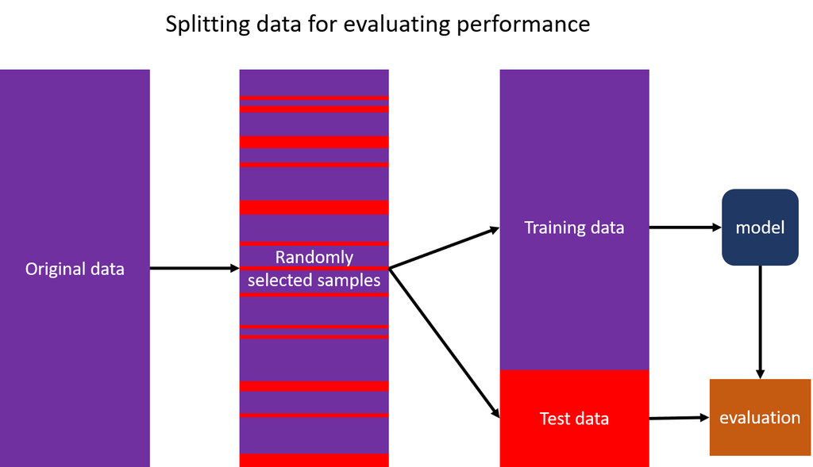

Figure 4.1: By randomly sampling from the original data, we hope that our training and test data are representative samples of the relationships we are trying to model.

### 3.1.1 Premature Featurisation

This first type of training example leakage is very easy to do from a programming perspective (in python for example, getting 4 characters wrong in your code will introduce this bias).

When we are exploring how to design our model we will make decisions based on the data we look at. If we make decisions based off of the whole data set, rather than just the data the model will be trained on then we are using information about the test data to create the model.

> If we look at the whole data set we will learn about the test set that we will later be splitting out for evaluation.

It is therefore crucial that we split our data into training and test sets before we explore or create features for the model.

Typically we have one big data set used for model training and testing. We need to split up this larger data set into the training and test data sets - this is done by random sampling typically.

Consider the following example:

We want to create a new feature based on the “mean radius” column of our data set. We are going to standardise the data, by subtracting the mean and dividing by the standard deviation for each record.

To do this we need to calculate two summary statistics: the mean of the data, and the standard deviation.

In our processing we therefore should calculate the mean and standard deviation from the **training** data, then use those values on the **test** data. If we calculate the mean and standard deviation using **both the training and test data** then the samples from the test data will influence the values calculated.

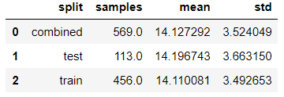

Figure 4.2: The standard scaler will use the mean and standard deviation of the population it is trained on. Giving different data sets will cause it to use different values, resulting in over-optimistic expectations later down the line.

It’s evident that our estimate of the mean and standard deviation will be more accurate by using the test data. Likewise, when testing this model on the test data, the scaling factors will be **nearer the correct quantity** for the test data than they would have been otherwise. This will result in our model performing better than it would have without data leakage, giving a more optimistic evaluation of the performance of our model.

While a model on data scaling is a simplified example of the impact of data leakage, we can see how model evaluation of models involving more complex elements, such as words/categories that the model otherwise wouldn’t have seen, could be even more heavily impacted by data leakage.

It’s important that we validate our model using testing data, but if this is skewed by data leakage we will be in for a nasty surprise when our model performs **worse** on real world predictions.

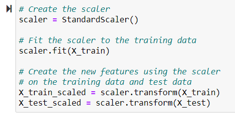

There are a number of ways to mitigate this form of data leakage:

- **Split Early** - ensure you have a hold out data set before any exploration, ideally stored separately from the training data.
- **Be careful** - peer review the work and specifically looking for data leakage can help avoid it.
- **Use pipelines** - modules for most modern machine learning libraries allow you to combine steps in a workflow that helps prevent accidental leakage.

Finally, be sure to ask the following quality questions:

**Quality Questions**

1. What? steps have been taken to avoid data leakage?
2. How? “held out” was the test/validation set?
3. When? At what stage is the data split, and when are the features created?

### 3.1.2 Duplication

Often the data given for training is not perfect and ready to be trained with. We make a range of processing decisions to format and clean this data to make it “model ready”. For instance, we may need to check the data for duplicates.

When these processing choices change the samples by creating new samples, we are at risk of data leakage.

It is tempting to create new instances of existing data points to “re-balance” the data set, or to “augment” the examples by duplicating and then altering the duplicates some way.

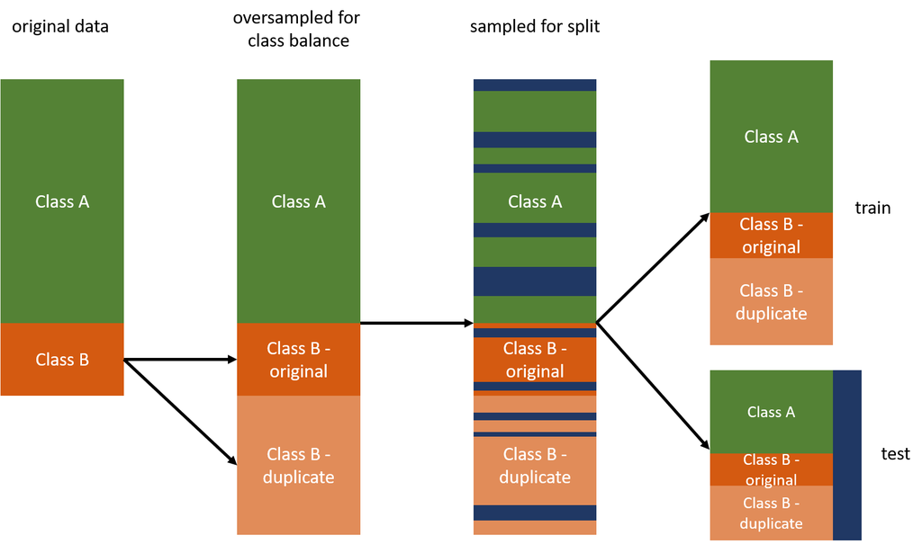

Figure 4.4: If duplicates exist before the training test split then there will be identical examples both trained on and evaluated on, giving an overly positive estimation of performance.

Common examples:

- **Missing duplicates** - Forgetting to check training data for duplicates
- **Over sampling** - if we have lots of class A, and few instances of class B, we may be tempted to repeat the samples of class B until the data is more balanced between A and B.
- **Data Augmentation** - if we have few samples of images to classify with, we may repeat images each with a rotation, skew or some other transformation to help our model learn.

The second two examples are not inherently bad, but they can easily lead to data leakage.

If we create duplicates or augment our data set **before we split our training and test sets** then identical or similar instances will exist in both the training and test data sets. This will skew our evaluation of the model, as the model will have already seen the data during training that is subsequently used to measure its performance.

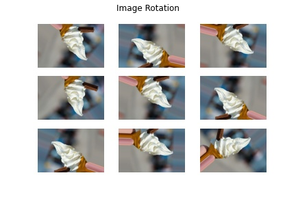

Figure 4.5: Augmenting data can help generalise a model, in the example of rotation this can prevent a model learning a specific orientation rather than the object it is trying to detect. If we do this before splitting the data however, we will have the same image in both the training and test data. For some data we augment it by some random amount, which means the difference between the original data and augmented can be very small for some samples.

Again, there’s little *inherently* wrong with data augmentation and re-sampling. But if we use those techniques we have to be sure it isn’t leading to data leakage, and we need to be aware that we are adding a form of bias.

**Quality Questions**

Has data been augmented / created and where in the process does this happen?

Is the model evaluated using duplicate samples?

A particularly famous example of sample leakage can be found in [this tweet](https://twitter.com/nizkroberts/status/931121395748270080) which caused the original paper referenced to be re-written with poorer model evaluation results.

The training and test data sets of pneumonia patients contained examples of the **same** patients. The images were not duplicates, but did refer to the same entity (patient in this case), meaning that the model was able to partially learn about the patient, rather than the desired relationship. This type of leakage is referred to as **group leakage**.

### 3.1.3 Independent Identically Distributed Data

A key assumption we make when evaluating the performance of a model is that the data it was trained with is:

- **Independent** of the other samples
- **Identically Distributed** - the samples come from the same population

When these assumptions are not held data leakage can easily occur.

For example, consider the sale of ice cream over a number of years. The number of sales on a given day will be impacted by the attributes of that day (e.g. the weather, if it’s a weekend and so on). However, they will also be influenced by what has happened the day before, if it was great weather the day before individuals may be more inclined to purchase an ice cream that day.

Therefore the data is not independent of other samples. If we split up the data at random we are not following the assumption of independence. There will be trends (e.g a decline in sales over time for example) that will not be captured, this means that each sample is not identically distributed either, the population is moving over time.

If we train with day $n_{-1}$, and day $n_{+1}$, and test on day $n_0$ then we have data leakage, our model will have learned information about the test sample it shouldn’t have.

Instead of randomly splitting our time series data, we should train the model on past data, then test it on a held out newer data set.

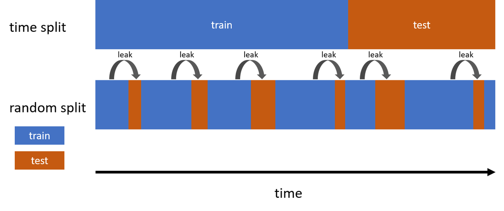

Figure 4.6: Data samples that are not independent need to be treated differently when evaluating and designing a model or else we will bake in information leakage into the process.

**Quality Questions**

Are the samples independent?

Are the samples from the same distribution?

Is a random split appropriate for this evaluation?

## 3.2 Feature Leakage

We have first looked at how we can leak information to our model through samples in a row-wise way, i.e. which observations are selected, we will now discuss feature leakage or column-wise leakage.

**Feature leakage** happens when we give a model a feature that it shouldn’t have been able to see.

These are generally:

- Including the target in the data set (giving it an **X** which includes what we are predicting **y**)
- Including a proxy for the target in the data set

The first is very easy to do as a programming error. We can forget to drop the target variable from a data frame by excluding a single line of code.

[figure not shown]

Figure 4.7: When the thing we are trying to predict is given to the model to train on as a feature it’s really easy to learn the relationship.

Our model will perform **exceptionally** well if we do this. The data we are training the model on literally has the answer we are looking for within it. It’s like giving the answer sheet to the test to a student taking the exam.

While it’s obvious we shouldn’t do this, I can’t stress how common a mistake this is. It is normally caught due to a models suspiciously high performance, but nonetheless it is important to be vigilant. This target information will be available for training and test sets, but when it comes to the real-world deployment this information will not be available, causing the model to either break or perform poorly.

It’s important that our model is interpretable in this case too. If we have one feature that is disproportionately doing the “heavy lifting” of the prediction it may be a proxy for the thing we are trying to predict.

It can be challenging to work out if a feature is a proxy for the outcome. In a way, all features are weak proxies for the outcome. After all we are using them to predict the outcome, therefore there must be some relationship? When we discuss proxies in the context of feature leakage we are referring to data that is **directly** related to the outcome, such as a restructuring of the outcome. This often occurs when we haven’t inspected our data for potential biases like proxies, and “trimmed” our data set accordingly before training.

For example, if we tried to predict whether or not an individual bought an ice cream on a given day, including the column “ate-cone”, which contains a True/False as to whether the person ate the cone and missing values otherwise would be a feature leakage. We can tell whether the individual had an ice-cream based on whether they have a value for “ate-cone” or not.

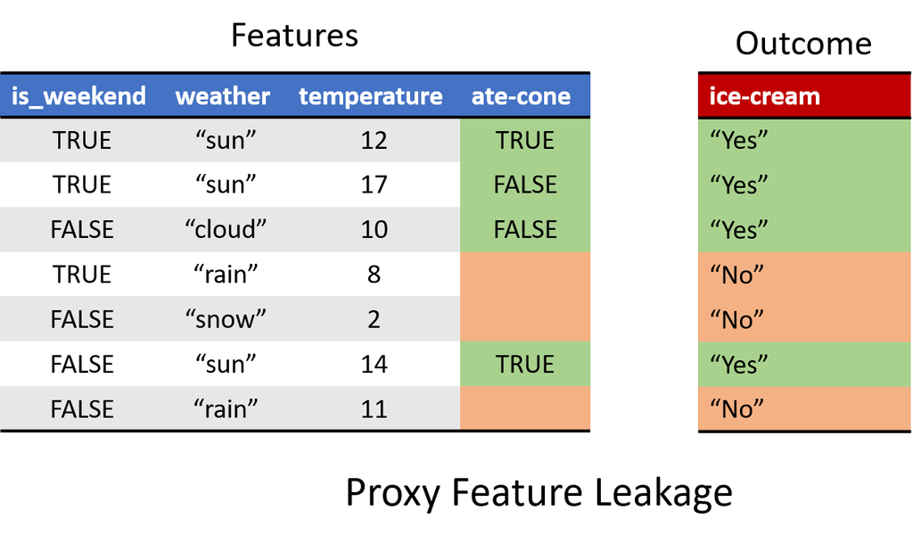

Figure 4.8: Proxies for what we are trying to predict can be added to the feature set causing leakage and overly optimistic evaluation.

**Quality Questions**

What are the features of the model?

Could any of the features be proxies for the target?

Do any of the features account for a substantial part of the prediction?

## 3.3 Discussion

**Question**

If we have two records in the data set with the same values, should we remove them?

**Answer**

It depends!

If the repeats are a result of duplication (in collection and processing), and we know this then yes we should remove them. Duplicate data adds bias, over representing a certain set of values which may not be representative of what we are modelling.

If the repeats are because, for example two individuals have the same name and date of birth then that’s okay! If we were to remove a value just because it occurs multiple times then we would be biasing the data in the other direction. If lots of people have the same name our data should represent that!

This comes down to *entity resolution*, does the data represent separate entities or the same entity (e.g. an individual)? Working this out can be tricky, and is linked to data storage and collection.

# 4 Sample Imbalance

A reminder: any model is a combination of the algorithm chosen, the data given to it, and the decisions we made along the way.

If we give an algorithm “unbalanced” data, we will get an unbalanced model.

What does “unbalanced” mean? In the most simple case it means more of one value in the data than the other.

Real data is often unbalanced, there are often many more people without a disease we are trying to detect that those with it. There are far more people near median income than with extremely high incomes.

Our model can only predict based on what it has seen, if it has seen more of a certain type of data point, it will naturally think that that data point is more likely to occur (the mechanism of this depends on the model).

This leads us to an interesting problem, to improve our models performance for different breakdowns we may need to make our training data **less** representative of the overall population, to make it better at predicting for that same population.

This problem directly links to the “More Data” section of module 2. Ideally, to improve model performance we gather more data, particularly of some underrepresented group. As we saw in the previous section, the attributes (risk or body-styles of cars) with fewer examples tended to have higher associated error in prediction. We simply can’t learn well what we haven’t seen much of before.

## 4.1 Effects of Class Imbalances

We are going to explore the discrete case of imbalances, for a classification problem (it is easier to visualize), but the same trend and challenge exists in continuous prediction.

We will focus on the imbalance of the target/label/value we are trying to predict, however, this can be weakly transferred to any feature in the data set.

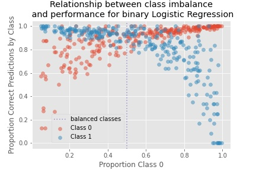

Figure 4.9: The best joint performance comes when both classes have an equal proportion. As one class dominates the performance of the other class suffers. Figure produced using a synthetic data set randomly sampling proportions of classes and performing logistic regression, evaluated on a heldout test set.

Broadly we say that as the class imbalance increases (difference in proportion) the performance of prediction for the less common class decreases. We therefore need to strike a balance between improving the performance of one class with the other.

If we have imbalanced classes and are not taking them into account, we are setting up the model for failure, which will, as we saw in the last module, disproportionately affect some groups present in our data.

**Quality Questions**

How imbalanced is the phenomena being modeled?

How imbalanced was the training data used to create this model?

## 4.2 Mitigating Class Imbalance

Our data in the real world will be imbalanced, unless we are very lucky (if we are lucky, it’s probably worth double checking why we have a balanced sample, has some unknown preprocessing occurred?).

We want to build models that perform either:

- Equally well for all classes
- or, the correct level for the situation we care about.

For that second case, consider again predicting a rare outcome, such as a disease. Without getting into too much detail with true/false positives/negative predictions, we don’t always want our classes to be equal, but we will want to change how the model takes different samples into account.

### 4.2.1 Gather More Data

**This is the preferred option.**

Even if the real population is imbalanced, collecting more data from the smallest class will give the model more information to make better predictions.

**Our training data does not need to be representative of balance between different groups**.

This may seem to go against some of the thoughts in the ethical applications module. However, what this means is that:

- different groups should be well represented in the training data, so that their characteristics can be learned
- the training data does not need to represent of the structure in society / populations to achieve the above

Adding data from classes with fewer instances improves model performance, which makes the model more equitable.

This approach is not always possible, but it should be the first one tried. The below two methods use statistical techniques to re-balance a data set in favour of an underrepresented class.

### 4.2.2 Re-sampling

When discussing re-sampling, and any row-based manipulation of the training data we need to keep in mind how we avoid data leakage, as discussed in the previous section.

If we cannot collect more data, then we can take further advantage of the data we already have to provide this balance. This method is not without its downsides, bias can still easily be introduced, but in some cases this can be a sensible approach.

**Oversample**

The first approach is to produce new data points from the class with the least data. The most naive approach is to create duplicate data points by sampling the class with the least data until some required count is reached.

This can improve model performance, but it’s important to remember that this will add bias into the data set. If the class with the least data was not very representative, by oversampling we propagate that problem further.

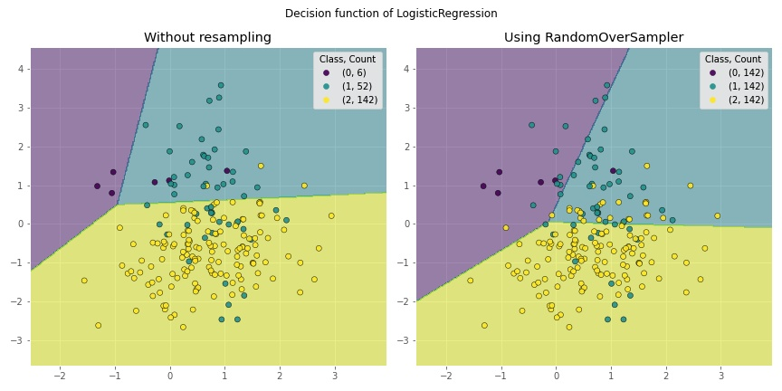

Figure 4.10: Oversampling from the smaller class gives the model more instances to learn from, even though they aren’t adding unique information to the data set. The smaller classes will be sampled until there is a balance across classes. Note that the oversampled points are not visible on the plot - because they are at the same position as the existing points.

The above approach is a naive method, more advanced methods make more sense to use in practice such as [SMOTE](https://bmcbioinformatics.biomedcentral.com/articles/10.1186/1471-2105-14-106) and it’s variants.

**Undersample**

This approach creates balance in the data set by randomly removing data points from the majority classes until they have the same number of data points as the smaller classes. This however removes a lot of useful information from our model with the hope of re-balancing the data set.

This approach is most useful when we know we have a very representative sample of the majority class already, and that we do not want to bias the model by oversampling the larger class.

As discussed previously, we tend to want more data, rather than less. However, in comparison to oversampling this doesn’t add bias as explicitly.

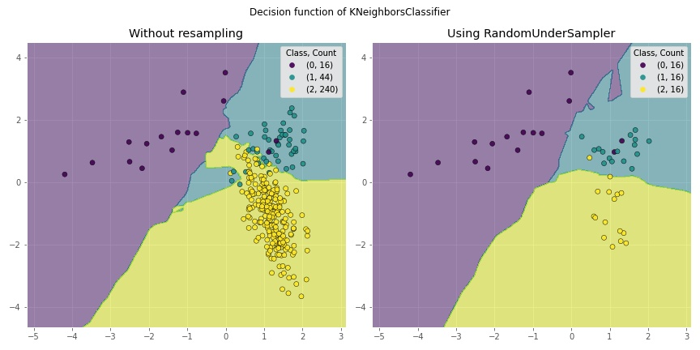

Figure 4.11: Undersampling causes us to lose many data points, but this does make our classes balanced. This can help reduce the dominance of a class. Some model types, such as the K nearest neighbour family are highly sensitive to counts of data points (K in this case!), so even with less data the decision boundaries can be improved.

Again, the method shown is naive, many more advanced approaches exist such as SMOTE, clustering and Tomek links.

- [This blog describes and compares Tomek links to SMOTE, an alternative approach](https://blog.dominodatalab.com/imbalanced-datasets/)
- [This paper gives an overview of cluster based under-sampling methods](http://www.iaeng.org/publication/WCE2013/WCE2013_pp1480-1485.pdf)

In fact, we can use a combination of over and undersampling methods to achieve a balance, getting the best (and worst) of both worlds.

**Quality Questions**

Could over/under-sampling reduce bias for certain classes?

Is there enough data to perform sample based balancing?

### 4.2.3 Weighting

As discussed in the *More Data* section of Module 2, not all data is created equally.

Therefore, our model’s shouldn’t need to treat every data point equally.

By re-weighting the classes a model sees we can re-balance the predictions.

This in effect penalizes different prediction errors by different amounts.

Getting a prediction of a smaller class is much worse for our re-balancing than incorrectly predicting a larger class.

We can decide **how much** we want to re-weight the classes in our data set, depending on what our goals are.

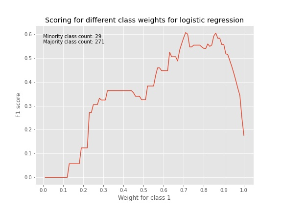

Not all model types allow us to re-weight the classes, those that can include: linear models, decision trees, support vector machines.

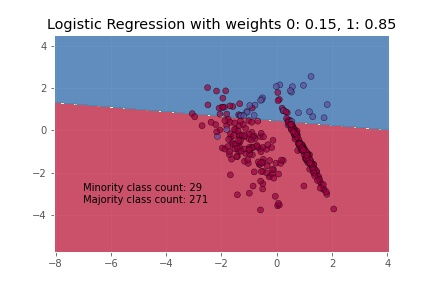

Figure 4.13: Logistic Regression binary task on synthetic data. By giving different classes different weights we can shift the resulting decision boundaries. This will help us stress the importance of some classes, without needing to duplicate / remove data points.

**Quality Questions**

Are the models classes / outcomes appropriately weighted?

If there is significant class imbalance in the original data, what steps have been taken to address this?

# 5 Validation

To this point we have mentioned that the use of a test set is important to have an **unbiased estimate** of a model’s performance. This is important so that we can have a more realistic approximation for how well our model will perform in the wild.

If we evaluate the performance of our model on data the model has been trained with, we will have an over optimistic view of it.

Ensuring that we use a robust methodology for measuring the performance gives us greater confidence in the “realworld” performance and generalisability of our model. While we can’t know *exactly* how well it will perform on unseen real data, using a held out data set gives us an indication.

**How we measure performance** How we measure the performance of a model is tied to two things:

- What we value, there are a range of metrics we may care about (**precision**, **recall**, **accuracy** and so on), what we value tells us which to choose.
  - This module will not cover in detail what each of these is for, general statistics literature is much better suited.
- How much data we have
  - Some methods are not feasible for small data sets, some are overkill for large data sets

In this part of the module we will assume we are evaluating a model for which thousands of records and available, and the true relationship trying to be learned is relatively simple.

## 5.1 Three Way Holdout

So far in the examples presented, two sets of data have been used, a training set and test set. This is fine for basic training examples, however, doing this can be problematic from an evaluation perspective.

If we want to evaluate a model on unseen data, we can’t have used that data **at any step previously to producing the model we want to evaluate**.

Consider the following work flow:

1. We split our data into a training and test set
2. We train the model using the training data
3. We evaluate the model on the test data
4. We tweak the model parameters to improve performance
5. We evaluate the model again on the **same** test data set
6. The model has improved so we report the performance of the new model on the test data set

This may seem like a reasonable workflow, but for many modelling cases this will produce a biased estimate. In step 5) we were looking to measure the performance, but used a test set which we had already evaluated on. This means the change we made to the model will be to suit the test data better, not **necessarily generalize the model better**.

If we wanted an unbiased estimate, once we have tweaked and decided how to improve the model we can **add another test set to evaluate with**. This is where the naming becomes less than ideal.

So instead of a train and test splits we have:

- A training set - used to train a model
- A **validation** set - used to improve the model, decide how to optimize
- A test set - used only at the end of the design process to evaluate performance

This way we can change the model’s parameters or design choices, estimate the performance to aid this, and then at the end to get a less biased measure use the final held out test set.

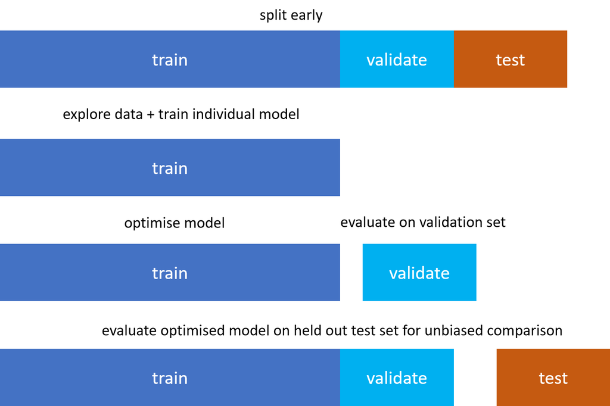

Figure 4.14: Utilising three separate data sets allows us to avoid overfitting the model to the test data set.

Typically, the data will be split along the lines of: **Training** (60%), **Validation** (20%) and **Test** (20%). If we do not have enough data to have representative samples in each set then other methods may be needed.

**Quality Questions**

How much has the test data set been used to influence the model design?

## 5.2 Cross Validation

Our models are a combination of the data (including processing) and learning algorithm chosen.

It’s important we understand whether the model we have is a true good model, or just one of many possible similar good models.

How this model performs differently when given different data is referred to as the **model variance**. High model variance tells us that we should be cautious about interpreting our model, and how well it will generalize to unseen data.

If we keep the learning algorithm constant, and data processing, then give our model slightly different collections of data we can estimate how well the model varies when trained and tested on different data.

If our model performs significantly different across different subsets of data it tells us we may have unrepresentative samples of data to train on, or that the model is overfitting to the **data specific instances of the training data, rather than learning a general trend.**

With respect to our previous data splits we would typically cross validate on the training data set alone, or perhaps if not much data was available a combination of the training and validation data set. **We still want a held out test data set to get an unbiased evaluation of the final model**.

### 5.2.1 K-Fold Cross Validation

The most common type of cross validation is called **K-fold cross validation**, where **K** is an integer.

The data set is randomly sampled into **K** equally size subsets.

The model is trained **K** times, on **K-1** combined sets, and evaluated on the other set.

This way we get **K** different models, that have been evaluated on every individual point in the data set.

Each model trained is trained on slightly different sets of data, which will cause each model to be slightly different. How different they are is our variance. As each model is evaluated on a different test set, we get a broader understanding of the performance of the model, rather than just one single evaluation.

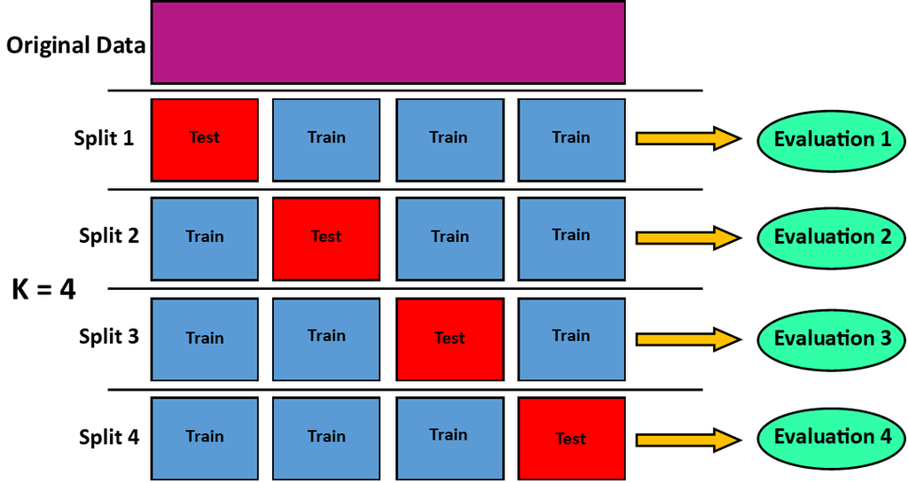

Figure 4.15: An example split of training data for cross validating a model. In this example K=4. Typically we choose K=3-5. The lower K the bigger our test sets for a representative evaluation, but this comes at the cost of less data to train with.

If our model has high variance in estimate, or a substantial range, we will have different confidence in any performance we get from later models using this same learning algorithm. Some models are well known as having high variance, and typically corresponding low bias. This is yet another trade-off we need to keep in mind when comparing models for use.

We can have situations where a model has a higher overall performance (such as mean accuracy across folds), but higher variance than another model. This ties into our confidence in the model.

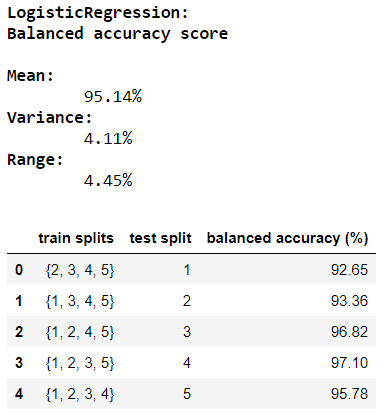

If our model’s performance can change significantly based on small deviations in input data, we need to be careful interpreting it, and ensure that we use a held out data set to evaluate and compare models.

**Quality Questions**

How much does the model vary with different input data?

If we have very small data sets we may choose to have $K=n\_samples$, that way we get a prediction for every sample, and use as much data to train as possible. This will allow us to estimate the performance for a range of samples and approximate the performance with a significant training set. This method is called **“Leave One Out”** cross validation.

## 5.3 Stratification

Remember in the previous section we discussed bias issues when it comes to class imbalances. If we have too much or too little of a certain type of data this will skew our model. However, even if we have a robust balance in the training set, when we cross validate on this set we are completely dependent on random sampling to preserve whatever balance we have constructed.

The act of **stratifying** our data set ensures we maintain a balance of classes when we split the data, such as in each k-fold in cross validation.

This becomes particularly important when our folds becomes small, as we are more likely to have unrepresentative samples for each fold. The results of each fold will be significantly impacted by individual data points in that fold.

If we have folds that are unrepresentative of our overall class balance we will have artificially high variance in our cross-validated model evaluation. Some folds will contain much more class A, than class B, which may drag down performance. Any aggregate we perform on the performance of the folds will be skewed by this effect.

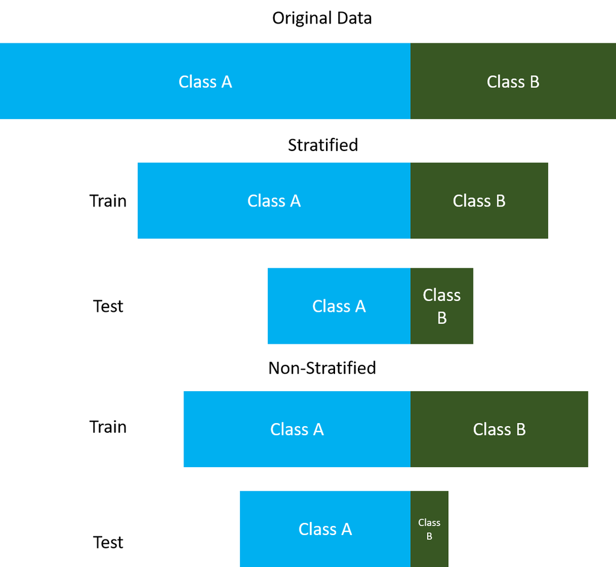

Figure 4.17: If the balance of classes are not maintained when we split the data our evaluation may be biased. We may deprive our model of adequate training examples of a type of data, then evaluate it against more instances of that type.

By maintaining a class balance we can estimate performance more accurately, reducing one effect of model variance. However, we may not have that same class balance in the real world!

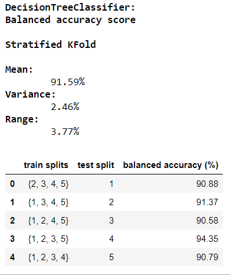

This effect is much more important when we have fewer data points. We want to be sure that the way we are evaluating a model aligns with what we are actually trying to understand from it.

**Quality Questions**

Are the data sets being evaluated with appropriately distributed?

## 5.4 Data Set Size

The approach of data splitting and evaluation is largely depended on how much data is available.

If we have millions of records, then we can use substantial amounts to test our model’s performance. The marginal gain in training data for performance is small compared to what we can learn about the models performance in unseen data.

When the data sets are smaller, we need to make each point count more, while still not biasing our evaluation.

In addition, another concern for data set size and cross validation at the large end can be model training time. If you need to train a different model for each split of the data, and each training takes a long time, that may be prohibitive. This issue can be compounded when we are searching for optimal parameters, as we will discuss in the next section.

For further information on model comparison and evaluation [this paper is gives an excellent summary of approaches out there](https://arxiv.org/pdf/1811.12808.pdf).

**Quality Questions**

Has the data been separated for training and testing in an appropriate way?

**In an ideal world we would have more training data than we need, and can therefore evaluate our model in a range of contexts. A good aim is to obtain a held-out test data set that was collected separately from the training data. This will help give and estimate that is missing some of the bias’ obtained in collection.**

We would consider this type of held out separate group data set the gold standard to evaluate against.

# 6 Model Hyper-parameter Optimization

Most models not only have data as an input, they are flexible learning algorithms that have another set of “settings”. These **hyper-parameters** set the way in which the algorithm will learn. At some point, we need to choose these values, or at least find out what a good set of them are.

There are many different hyper-parameters that can be tuned for different learning algorithms, each model type will have a different set of values, the parameters for a decision tree will be mostly different from a logistic regression.

While modern statistical packages allow us to easily use different model types, it is up to the analyst to use their expertise to determine what hyper-parameters are important to get the best performance out of the model.

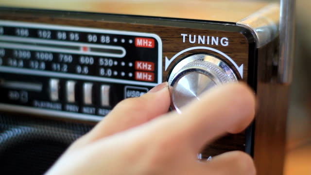

Figure 4.19: We need to search for the best (or good enough) hyper-parameter values. We can’t know exactly what the best values will be before testing the model, which means we need to create lots of models with different hyper-parameter values and compare how they perform.

Some common hyper-parameters:

- Regularization coefficients (how much to penalise high coefficient values)
- Solving algorithm (which approach to solving an optimisation problem)
- Solving algorithm tolerance threshold (at what point to stop solving the optimisation problem)
- Class weights (the balance of each target value)
- and many more specific to each model

The software packages will come with some default hyper-parameters which are often reasonable starting points. However, if we want to improve the performance of our algorithm we will need to **search** for a better combination of hyper parameter values.

Searching for optimal hyper-parameters is an occasional double-edged sword. Because of the flexibility of our algorithms we can select better hyper-parameters for the task at hand, great. However, this **introduces the possibility that we overfit the model to the specific data set**. So the flexibility of the model needs to be balanced. If we select a set of hyper-parameters that perform really well on our training data, they may not perform well on our test data. Remember: we care about the performance on a held out set because it is a better approximation of real data the model will see in practice.

Over-fitting happens when our model captures **signal and noise**, whereas we only want **signal**.

**Quality Questions**

What investigations into appropriate hyper-parameters have been conducted?

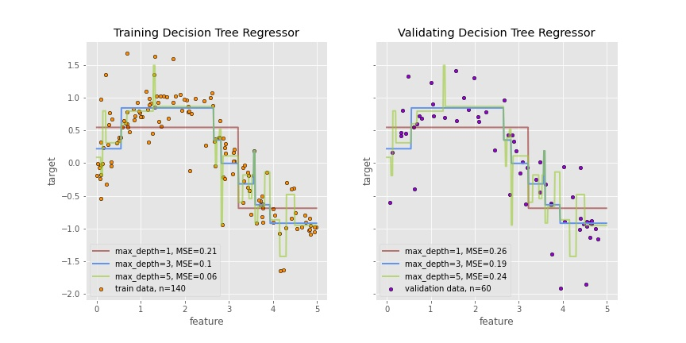

Figure 4.20: Three decision trees are trained on identical data. The only difference is the value for the hyper-parameter ‘max_depth’ the maximum number of branches to a node in the tree. The more branches deep there is, the more complex a phenomena can be modelled. For this data (a sine wave with gaussian noise) having only 1 depth causes a bad ‘under’ fit. The model is bad compared to the others for both training and testing. For the highest depth of 5, the model performs really well on the training data, but poorly on the test data. In this case the model is too flexible and overfit to the specifics of the data (see where it stretches up and down to individual outliers). The goldilocks model in this case has, ‘max_depth=3’ being flexible enough to get the signal, but not the noise.

Models should perform better on predicting the training set than the validation / test sets, after all it has seen that data. How much worse the model is at predicting the validation/test set is compared to the training set is a strong indicator of overfitting.

If our model performs better on the test data than the training, we should double check for data leakage! It is possible for this inverted performance to occur, particularly at small sample sizes, but it is unlikely.

Our example in the figure above is quite simple, there is only one feature and we can easily visualize the overfitting. However, for most cases we will need to rely on comparing evaluation metrics such as the mean squared error as shown. It can be difficult to measure overfitting in an *absolute* way, this is why model comparison and using sensible baselines are key.

In the classification example, we are more at risk of being influenced by class imbalances when our model is highly flexible and can overfit.

Some important steps to avoid overfitting:

- Keep models simple
- Evaluate robustly on held-out data
- Search through a **variety** of hyper-parameters
- Provide adequate data
- Regularize coefficients (or early stopping/dropout for deep learning)
- Use cross-validation methods when searching for the best hyper-parameters

Under-fitting too can be an issue, however, this is more often just viewed as a poor performing model. This will likely happen when too simple a model / feature set is used for a complex phenomena.

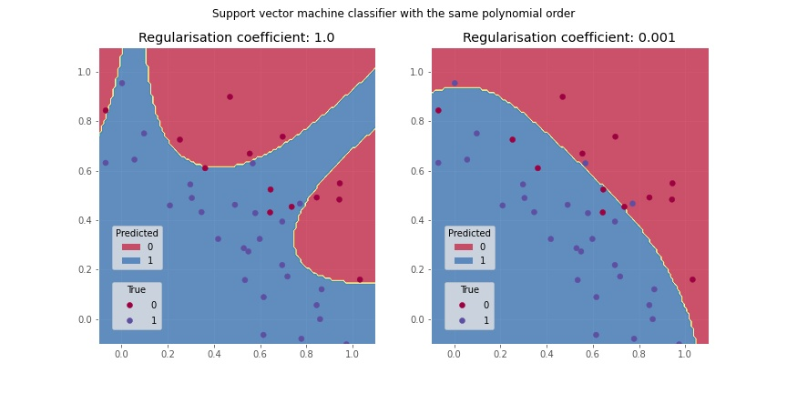

Figure 4.21: Even with a very flexible model (SVM of degree 7) we can reduce the overfitting with the correct hyperparameter selection. In this case, the default regularisation wasn’t penalising the coefficients enough.

**Quality Questions**

Is the model overfitting and what proof do you have that it isn’t?

## 6.1 Discussion

**Question**

Given we need to try out hyper-parameter values to determine how well they perform, what ways do you think we can search for the best (or good) values?

**Suggestion**

In practice to find optimal hyper-parameters we select a range of values that we would like to look through. We then select either through an exhaustive search or random sampling different combinations of parameters to find the best cross validated value. We can then evaluated the optimal model on the test data to compare with other models.

More advanced methods treat this as an explicit optimisation problem, where we start at a given set of hyper-parameters, evaluate, then choose a direction and distance to travel in hyper-parameter space until a satisfactory value is found.

# 7 Summary

In this chapter we have further explored how different forms of statistical bias can creep into predictive modelling systems.

Specifically we explored:

- What the different forms of data leakage are and how they can impact models
- The challenges relating to imbalanced training data and different approaches to minimizing the effects
- Proper evaluation techniques for unbiased estimates of model performance with held out data sets
- How hyper-parameters can impact the performance of a model positively or negatively, and how to check for overfitting.

All models have bias, what we need to do is minimize the biases which negatively impact our aims. Our aims may be equitable prediction for different groups for example, or maximizing predictive performance. Without awareness of common ways that bias can accidentally enter the model we wouldn’t be able to spot them or ask the right questions of analysts to find them.

In the next module we will explore different forms of model interpretability in depth to understand what sort of questions we should ask about predictive models.